# Analyse des données de la Premiere League

**Objectif:** Proposer au client Les meilleurs buteurs!

```python
# importer packages
import numpy as np
import pandas as pd
import matplotlib.pyplot as plt
import seaborn as sns
```

[figure not shown]

```python
from IPython.display import Image
Image(filename='premiere league.png', width=300, height=200)
```

# Importation des données

```python
df=pd.read_csv('Football Players Stats (Premier League 2021-2022).csv',encoding='ISO-8859-1')
df
```

|  | Player | Team | Nation | Pos | Age | MP | Starts | Min | 90s | Gls | ... | G+A-PK | xG | npxG | xA | npxG+xA | xG.1 | xA.1 | xG+xA | npxG.1 | npxG+xA.1 |
| --- | --- | --- | --- | --- | --- | --- | --- | --- | --- | --- | --- | --- | --- | --- | --- | --- | --- | --- | --- | --- | --- |
| 0 | Bukayo Saka | Arsenal | eng ENG | FW,MF | 19.0 | 38 | 36 | 2,978 | 33.1 | 11.0 | ... | 0.48 | 9.7 | 8.2 | 6.9 | 15.2 | 0.29 | 0.21 | 0.50 | 0.25 | 0.46 |
| 1 | Gabriel Dos Santos | Arsenal | br BRA | DF | 23.0 | 35 | 35 | 3,063 | 34.0 | 5.0 | ... | 0.15 | 2.7 | 2.7 | 0.8 | 3.5 | 0.08 | 0.02 | 0.10 | 0.08 | 0.10 |
| 2 | Aaron Ramsdale | Arsenal | eng ENG | GK | 23.0 | 34 | 34 | 3,060 | 34.0 | 0.0 | ... | 0.00 | 0.0 | 0.0 | 0.0 | 0.0 | 0.00 | 0.00 | 0.00 | 0.00 | 0.00 |
| 3 | Ben White | Arsenal | eng ENG | DF | 23.0 | 32 | 32 | 2,880 | 32.0 | 0.0 | ... | 0.00 | 1.0 | 1.0 | 0.6 | 1.6 | 0.03 | 0.02 | 0.05 | 0.03 | 0.05 |
| 4 | Martin Ødegaard | Arsenal | no NOR | MF | 22.0 | 36 | 32 | 2,785 | 30.9 | 7.0 | ... | 0.36 | 4.8 | 4.8 | 6.8 | 11.6 | 0.16 | 0.22 | 0.38 | 0.16 | 0.38 |
| ... | ... | ... | ... | ... | ... | ... | ... | ... | ... | ... | ... | ... | ... | ... | ... | ... | ... | ... | ... | ... | ... |
| 686 | Christian Marques | Wolverhampton Wanderers | ch SUI | DF | 18.0 | 0 | 0 | NaN | NaN | NaN | ... | NaN | NaN | NaN | NaN | NaN | NaN | NaN | NaN | NaN | NaN |
| 687 | Yerson Mosquera | Wolverhampton Wanderers | co COL | DF | 20.0 | 0 | 0 | NaN | NaN | NaN | ... | NaN | NaN | NaN | NaN | NaN | NaN | NaN | NaN | NaN | NaN |
| 688 | Louie Moulden | Wolverhampton Wanderers | eng ENG | GK | 19.0 | 0 | 0 | NaN | NaN | NaN | ... | NaN | NaN | NaN | NaN | NaN | NaN | NaN | NaN | NaN | NaN |
| 689 | Dion Sanderson | Wolverhampton Wanderers | eng ENG | DF | 21.0 | 0 | 0 | NaN | NaN | NaN | ... | NaN | NaN | NaN | NaN | NaN | NaN | NaN | NaN | NaN | NaN |
| 690 | James Storer | Wolverhampton Wanderers | NaN | GK | NaN | 0 | 0 | NaN | NaN | NaN | ... | NaN | NaN | NaN | NaN | NaN | NaN | NaN | NaN | NaN | NaN |

691 rows × 30 columns

```python
df.info()
```

```
<class 'pandas.core.frame.DataFrame'>
RangeIndex: 691 entries, 0 to 690
Data columns (total 30 columns):
 #   Column     Non-Null Count  Dtype
---  ------     --------------  -----
 0   Player     691 non-null    object
 1   Team       691 non-null    object
 2   Nation     688 non-null    object
 3   Pos        691 non-null    object
 4   Age        687 non-null    float64
 5   MP         691 non-null    int64
 6   Starts     691 non-null    int64
 7   Min        546 non-null    object
 8   90s        547 non-null    float64
 9   Gls        547 non-null    float64
```

[output cut: 22 more lines]

```python
df['Pos'].unique()
```

```
array(['FW,MF', 'DF', 'GK', 'MF', 'MF,DF', 'MF,FW', 'FW', 'DF,MF',
       'DF,FW', 'FW,DF'], dtype=object)
```

# Evaluation des données

**Problèmes de qualités**

- Problème de type pour "Min"
- Valeurs manquantes

**Problèmes de structure**

- Pour la colonne "Nation": La meme information écrite deux fois: en majiscule et en miniscule, nous allons garder ce qui ecrit en majiscule.
- Pour la colnne "pos": nous allons prendre juste la premiere position du joueur

# Nettoyage de données

```python
# changement du type de min
```

On peut utiliser plusieurs méthodes:

- df['Min'].str.type("float")
- df['Min'].str.astype("float")
- pd.to_numeric(df['Min'])

```python
df.info()
```

```
<class 'pandas.core.frame.DataFrame'>
RangeIndex: 691 entries, 0 to 690
Data columns (total 30 columns):
 #   Column     Non-Null Count  Dtype
---  ------     --------------  -----
 0   Player     691 non-null    object
 1   Team       691 non-null    object
 2   Nation     688 non-null    object
 3   Pos        691 non-null    object
 4   Age        687 non-null    float64
 5   MP         691 non-null    int64
 6   Starts     691 non-null    int64
 7   Min        546 non-null    object
 8   90s        547 non-null    float64
 9   Gls        547 non-null    float64
```

[output cut: 22 more lines]

```python
# je dois d'abord supprimer la virgule
df['Min']=df['Min'].str.replace(',','')
```

```python
df['Min']=df['Min'].astype("float")
```

```python
# verification
df.info()
```

```
<class 'pandas.core.frame.DataFrame'>
RangeIndex: 691 entries, 0 to 690
Data columns (total 30 columns):
 #   Column     Non-Null Count  Dtype
---  ------     --------------  -----
 0   Player     691 non-null    object
 1   Team       691 non-null    object
 2   Nation     688 non-null    object
 3   Pos        691 non-null    object
 4   Age        687 non-null    float64
 5   MP         691 non-null    int64
 6   Starts     691 non-null    int64
 7   Min        546 non-null    float64
 8   90s        547 non-null    float64
 9   Gls        547 non-null    float64
```

[output cut: 22 more lines]

```python
# Valeurs manquantes
df.isnull().sum()
```

```
Player         0
Team           0
Nation         3
Pos            0
Age            4
MP             0
Starts         0
Min          145
90s          144
Gls          144
Ast          144
G-PK         144
PK           144
PKatt        144
CrdY         144
CrdR         144
Gls.1        145
Ast.1        145
G+A          145
G-PK.1       145
G+A-PK       145
xG           145
npxG         145
xA           145
npxG+xA      145
xG.1         145
xA.1         145
xG+xA        145
npxG.1       145
npxG+xA.1    145
dtype: int64
```

```python
df[df['Nation'].isnull()]
```

|  | Player | Team | Nation | Pos | Age | MP | Starts | Min | 90s | Gls | ... | G+A-PK | xG | npxG | xA | npxG+xA | xG.1 | xA.1 | xG+xA | npxG.1 | npxG+xA.1 |
| --- | --- | --- | --- | --- | --- | --- | --- | --- | --- | --- | --- | --- | --- | --- | --- | --- | --- | --- | --- | --- | --- |
| 318 | Kris Moore | Leeds United | NaN | MF | NaN | 0 | 0 | NaN | NaN | NaN | ... | NaN | NaN | NaN | NaN | NaN | NaN | NaN | NaN | NaN | NaN |
| 548 | Tyler Dibling | Southampton | NaN | MF | NaN | 0 | 0 | NaN | NaN | NaN | ... | NaN | NaN | NaN | NaN | NaN | NaN | NaN | NaN | NaN | NaN |
| 690 | James Storer | Wolverhampton Wanderers | NaN | GK | NaN | 0 | 0 | NaN | NaN | NaN | ... | NaN | NaN | NaN | NaN | NaN | NaN | NaN | NaN | NaN | NaN |

3 rows × 30 columns

```python
# suppression des valeurs manquantes
df=df.dropna()
```

```python
# verification
df.isnull().sum()
```

```
Player       0
Team         0
Nation       0
Pos          0
Age          0
MP           0
Starts       0
Min          0
90s          0
Gls          0
Ast          0
G-PK         0
PK           0
PKatt        0
CrdY         0
CrdR         0
Gls.1        0
Ast.1        0
G+A          0
G-PK.1       0
G+A-PK       0
xG           0
npxG         0
xA           0
npxG+xA      0
xG.1         0
xA.1         0
xG+xA        0
npxG.1       0
npxG+xA.1    0
dtype: int64
```

**Pour la colonne "Nation": La meme information écrite deux fois: en majiscule et en miniscule, nous allons garder ce qui ecrit en majiscule.**

```python
df['Nation']=df['Nation'].str.split().str[1]
```

```python
df
```

|  | Player | Team | Nation | Pos | Age | MP | Starts | Min | 90s | Gls | ... | G+A-PK | xG | npxG | xA | npxG+xA | xG.1 | xA.1 | xG+xA | npxG.1 | npxG+xA.1 |
| --- | --- | --- | --- | --- | --- | --- | --- | --- | --- | --- | --- | --- | --- | --- | --- | --- | --- | --- | --- | --- | --- |
| 0 | Bukayo Saka | Arsenal | ENG | FW,MF | 19.0 | 38 | 36 | 2978.0 | 33.1 | 11.0 | ... | 0.48 | 9.7 | 8.2 | 6.9 | 15.2 | 0.29 | 0.21 | 0.50 | 0.25 | 0.46 |
| 1 | Gabriel Dos Santos | Arsenal | BRA | DF | 23.0 | 35 | 35 | 3063.0 | 34.0 | 5.0 | ... | 0.15 | 2.7 | 2.7 | 0.8 | 3.5 | 0.08 | 0.02 | 0.10 | 0.08 | 0.10 |
| 2 | Aaron Ramsdale | Arsenal | ENG | GK | 23.0 | 34 | 34 | 3060.0 | 34.0 | 0.0 | ... | 0.00 | 0.0 | 0.0 | 0.0 | 0.0 | 0.00 | 0.00 | 0.00 | 0.00 | 0.00 |
| 3 | Ben White | Arsenal | ENG | DF | 23.0 | 32 | 32 | 2880.0 | 32.0 | 0.0 | ... | 0.00 | 1.0 | 1.0 | 0.6 | 1.6 | 0.03 | 0.02 | 0.05 | 0.03 | 0.05 |
| 4 | Martin Ødegaard | Arsenal | NOR | MF | 22.0 | 36 | 32 | 2785.0 | 30.9 | 7.0 | ... | 0.36 | 4.8 | 4.8 | 6.8 | 11.6 | 0.16 | 0.22 | 0.38 | 0.16 | 0.38 |
| ... | ... | ... | ... | ... | ... | ... | ... | ... | ... | ... | ... | ... | ... | ... | ... | ... | ... | ... | ... | ... | ... |
| 678 | Luke Cundle | Wolverhampton Wanderers | ENG | MF | 19.0 | 4 | 2 | 180.0 | 2.0 | 0.0 | ... | 0.00 | 0.0 | 0.0 | 0.2 | 0.2 | 0.00 | 0.12 | 0.12 | 0.00 | 0.12 |
| 679 | Chiquinho | Wolverhampton Wanderers | POR | DF,MF | 21.0 | 8 | 1 | 208.0 | 2.3 | 0.0 | ... | 1.30 | 0.3 | 0.3 | 0.6 | 0.9 | 0.13 | 0.27 | 0.41 | 0.13 | 0.41 |
| 680 | John Ruddy | Wolverhampton Wanderers | ENG | GK | 34.0 | 2 | 1 | 135.0 | 1.5 | 0.0 | ... | 0.00 | 0.0 | 0.0 | 0.0 | 0.0 | 0.00 | 0.00 | 0.00 | 0.00 | 0.00 |
| 681 | Chem Campbell | Wolverhampton Wanderers | WAL | MF | 18.0 | 1 | 0 | 13.0 | 0.1 | 0.0 | ... | 0.00 | 0.0 | 0.0 | 0.0 | 0.0 | 0.00 | 0.00 | 0.00 | 0.00 | 0.00 |
| 682 | Morgan Gibbs-White | Wolverhampton Wanderers | ENG | FW,MF | 21.0 | 2 | 0 | 9.0 | 0.1 | 0.0 | ... | 0.00 | 0.1 | 0.1 | 0.0 | 0.1 | 1.22 | 0.00 | 1.22 | 1.22 | 1.22 |

546 rows × 30 columns

```python
#Pour la colnne "pos": nous allons prendre juste la premiere position du joueur
df['Pos']=df['Pos'].str.split(',').str[0]
df
```

|  | Player | Team | Nation | Pos | Age | MP | Starts | Min | 90s | Gls | ... | G+A-PK | xG | npxG | xA | npxG+xA | xG.1 | xA.1 | xG+xA | npxG.1 | npxG+xA.1 |
| --- | --- | --- | --- | --- | --- | --- | --- | --- | --- | --- | --- | --- | --- | --- | --- | --- | --- | --- | --- | --- | --- |
| 0 | Bukayo Saka | Arsenal | ENG | FW | 19.0 | 38 | 36 | 2978.0 | 33.1 | 11.0 | ... | 0.48 | 9.7 | 8.2 | 6.9 | 15.2 | 0.29 | 0.21 | 0.50 | 0.25 | 0.46 |
| 1 | Gabriel Dos Santos | Arsenal | BRA | DF | 23.0 | 35 | 35 | 3063.0 | 34.0 | 5.0 | ... | 0.15 | 2.7 | 2.7 | 0.8 | 3.5 | 0.08 | 0.02 | 0.10 | 0.08 | 0.10 |
| 2 | Aaron Ramsdale | Arsenal | ENG | GK | 23.0 | 34 | 34 | 3060.0 | 34.0 | 0.0 | ... | 0.00 | 0.0 | 0.0 | 0.0 | 0.0 | 0.00 | 0.00 | 0.00 | 0.00 | 0.00 |
| 3 | Ben White | Arsenal | ENG | DF | 23.0 | 32 | 32 | 2880.0 | 32.0 | 0.0 | ... | 0.00 | 1.0 | 1.0 | 0.6 | 1.6 | 0.03 | 0.02 | 0.05 | 0.03 | 0.05 |
| 4 | Martin Ødegaard | Arsenal | NOR | MF | 22.0 | 36 | 32 | 2785.0 | 30.9 | 7.0 | ... | 0.36 | 4.8 | 4.8 | 6.8 | 11.6 | 0.16 | 0.22 | 0.38 | 0.16 | 0.38 |
| ... | ... | ... | ... | ... | ... | ... | ... | ... | ... | ... | ... | ... | ... | ... | ... | ... | ... | ... | ... | ... | ... |
| 678 | Luke Cundle | Wolverhampton Wanderers | ENG | MF | 19.0 | 4 | 2 | 180.0 | 2.0 | 0.0 | ... | 0.00 | 0.0 | 0.0 | 0.2 | 0.2 | 0.00 | 0.12 | 0.12 | 0.00 | 0.12 |
| 679 | Chiquinho | Wolverhampton Wanderers | POR | DF | 21.0 | 8 | 1 | 208.0 | 2.3 | 0.0 | ... | 1.30 | 0.3 | 0.3 | 0.6 | 0.9 | 0.13 | 0.27 | 0.41 | 0.13 | 0.41 |
| 680 | John Ruddy | Wolverhampton Wanderers | ENG | GK | 34.0 | 2 | 1 | 135.0 | 1.5 | 0.0 | ... | 0.00 | 0.0 | 0.0 | 0.0 | 0.0 | 0.00 | 0.00 | 0.00 | 0.00 | 0.00 |
| 681 | Chem Campbell | Wolverhampton Wanderers | WAL | MF | 18.0 | 1 | 0 | 13.0 | 0.1 | 0.0 | ... | 0.00 | 0.0 | 0.0 | 0.0 | 0.0 | 0.00 | 0.00 | 0.00 | 0.00 | 0.00 |
| 682 | Morgan Gibbs-White | Wolverhampton Wanderers | ENG | FW | 21.0 | 2 | 0 | 9.0 | 0.1 | 0.0 | ... | 0.00 | 0.1 | 0.1 | 0.0 | 0.1 | 1.22 | 0.00 | 1.22 | 1.22 | 1.22 |

546 rows × 30 columns

# Valeurs abberantes

L'objectif est de trouver les meilleurs joueurs, donc nous allons nous baser sur la colonne: "Gls : Goals scored or allowed" et nous allons chercher les valeurs abberantes

#### Methode Graphique

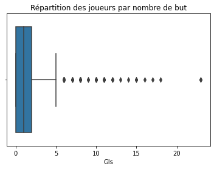

```python
sns.boxplot(df['Gls'])
plt.title('Répartition des joueurs par nombre de but')
plt.show()
```

On voit sortir quelques valeurs abberantes: c'est des joueurs qui marque plus de buts que la limite superieur.

#### Methode Analytique

```python
#On calcule d'abord les quartiles:
Q1=df['Gls'].quantile(0.25)
Q3=df['Gls'].quantile(0.75)
print(Q1,Q3)
```

```
0.0 2.0
```

```python
# autre méthode
df['Gls'].describe()
```

```
count    546.000000
mean       1.899267
std        3.257021
min        0.000000
25%        0.000000
50%        1.000000
75%        2.000000
max       23.000000
Name: Gls, dtype: float64
```

```python
# calcule de IQR
IQR=Q3-Q1
IQR
```

```
2.0
```

```python
#la limite superieur et la limite inf
sup=Q3+1.5*IQR
inf=Q1-1.5*IQR
print(sup,inf)
```

```
5.0 -3.0
```

```python
# Affichage des valeurs abberantes
buteurs=df[df['Gls']>sup]
buteurs
```

|  | Player | Team | Nation | Pos | Age | MP | Starts | Min | 90s | Gls | ... | G+A-PK | xG | npxG | xA | npxG+xA | xG.1 | xA.1 | xG+xA | npxG.1 | npxG+xA.1 |
| --- | --- | --- | --- | --- | --- | --- | --- | --- | --- | --- | --- | --- | --- | --- | --- | --- | --- | --- | --- | --- | --- |
| 0 | Bukayo Saka | Arsenal | ENG | FW | 19.0 | 38 | 36 | 2978.0 | 33.1 | 11.0 | ... | 0.48 | 9.7 | 8.2 | 6.9 | 15.2 | 0.29 | 0.21 | 0.50 | 0.25 | 0.46 |
| 4 | Martin Ødegaard | Arsenal | NOR | MF | 22.0 | 36 | 32 | 2785.0 | 30.9 | 7.0 | ... | 0.36 | 4.8 | 4.8 | 6.8 | 11.6 | 0.16 | 0.22 | 0.38 | 0.16 | 0.38 |
| 8 | Emile Smith Rowe | Arsenal | ENG | MF | 21.0 | 33 | 21 | 1921.0 | 21.3 | 10.0 | ... | 0.56 | 5.8 | 5.8 | 2.2 | 8.0 | 0.27 | 0.10 | 0.37 | 0.27 | 0.37 |
| 9 | Martinelli | Arsenal | BRA | FW | 20.0 | 29 | 21 | 1860.0 | 20.7 | 6.0 | ... | 0.53 | 7.2 | 6.5 | 3.3 | 9.8 | 0.35 | 0.16 | 0.51 | 0.31 | 0.47 |
| 45 | Ollie Watkins | Aston Villa | ENG | FW | 25.0 | 35 | 33 | 2952.0 | 32.8 | 11.0 | ... | 0.37 | 12.2 | 11.4 | 2.9 | 14.3 | 0.37 | 0.09 | 0.46 | 0.35 | 0.44 |
| 48 | Jacob Ramsey | Aston Villa | ENG | MF | 20.0 | 34 | 29 | 2467.0 | 27.4 | 6.0 | ... | 0.26 | 3.8 | 3.8 | 2.0 | 5.8 | 0.14 | 0.07 | 0.21 | 0.14 | 0.21 |
| 50 | Danny Ings | Aston Villa | ENG | FW | 29.0 | 30 | 22 | 1898.0 | 21.1 | 7.0 | ... | 0.57 | 7.3 | 6.6 | 2.0 | 8.6 | 0.35 | 0.10 | 0.44 | 0.31 | 0.41 |
| 86 | Ivan Toney | Brentford | ENG | FW | 25.0 | 33 | 32 | 2909.0 | 32.3 | 12.0 | ... | 0.37 | 12.0 | 8.2 | 5.8 | 14.0 | 0.37 | 0.18 | 0.55 | 0.25 | 0.43 |
| 93 | Yoane Wissa | Brentford | COD | FW | 24.0 | 30 | 12 | 1284.0 | 14.3 | 7.0 | ... | 0.56 | 3.7 | 3.7 | 0.7 | 4.4 | 0.26 | 0.05 | 0.31 | 0.26 | 0.31 |
| 121 | Leandro Trossard | Brighton & Hove Albion | BEL | FW | 26.0 | 34 | 32 | 2805.0 | 31.2 | 8.0 | ... | 0.32 | 6.8 | 6.0 | 4.1 | 10.1 | 0.22 | 0.13 | 0.35 | 0.19 | 0.32 |
| 123 | Neal Maupay | Brighton & Hove Albion | FRA | FW | 24.0 | 32 | 25 | 2276.0 | 25.3 | 8.0 | ... | 0.36 | 7.7 | 6.2 | 2.2 | 8.4 | 0.30 | 0.09 | 0.39 | 0.24 | 0.33 |
| 132 | Danny Welbeck | Brighton & Hove Albion | ENG | FW | 30.0 | 25 | 15 | 1478.0 | 16.4 | 6.0 | ... | 0.49 | 6.1 | 6.1 | 1.0 | 7.1 | 0.37 | 0.06 | 0.44 | 0.37 | 0.44 |
| 160 | Maxwel Cornet | Burnley | CIV | FW | 24.0 | 26 | 21 | 1766.0 | 19.6 | 9.0 | ... | 0.51 | 6.7 | 5.9 | 1.5 | 7.4 | 0.34 | 0.07 | 0.42 | 0.30 | 0.38 |
| 188 | Mason Mount | Chelsea | ENG | MF | 22.0 | 32 | 27 | 2363.0 | 26.3 | 11.0 | ... | 0.76 | 8.9 | 8.1 | 6.7 | 14.8 | 0.34 | 0.25 | 0.59 | 0.31 | 0.56 |
| 189 | Jorginho | Chelsea | ITA | MF | 29.0 | 29 | 26 | 2273.0 | 25.3 | 6.0 | ... | 0.08 | 5.7 | 0.4 | 2.8 | 3.2 | 0.23 | 0.11 | 0.34 | 0.02 | 0.13 |
| 193 | Kai Havertz | Chelsea | GER | FW | 22.0 | 29 | 22 | 1809.0 | 20.1 | 8.0 | ... | 0.55 | 9.7 | 9.7 | 2.0 | 11.6 | 0.48 | 0.10 | 0.58 | 0.48 | 0.58 |
| 197 | Romelu Lukaku | Chelsea | BEL | FW | 28.0 | 26 | 16 | 1589.0 | 17.7 | 8.0 | ... | 0.40 | 6.8 | 6.1 | 3.0 | 9.0 | 0.39 | 0.17 | 0.55 | 0.34 | 0.51 |
| 202 | Christian Pulisic | Chelsea | USA | MF | 22.0 | 22 | 13 | 1290.0 | 14.3 | 6.0 | ... | 0.56 | 5.1 | 5.1 | 1.2 | 6.3 | 0.35 | 0.08 | 0.44 | 0.35 | 0.44 |
| 218 | Conor Gallagher | Crystal Palace | ENG | MF | 21.0 | 34 | 33 | 2845.0 | 31.6 | 8.0 | ... | 0.35 | 5.8 | 5.8 | 3.5 | 9.3 | 0.18 | 0.11 | 0.29 | 0.18 | 0.29 |
| 220 | Wilfried Zaha | Crystal Palace | CIV | FW | 28.0 | 33 | 31 | 2760.0 | 30.7 | 14.0 | ... | 0.33 | 9.4 | 4.0 | 4.8 | 8.8 | 0.31 | 0.16 | 0.46 | 0.13 | 0.29 |
| 226 | Odsonne Édouard | Crystal Palace | FRA | FW | 23.0 | 28 | 18 | 1564.0 | 17.4 | 6.0 | ... | 0.46 | 6.9 | 6.1 | 2.3 | 8.4 | 0.39 | 0.13 | 0.53 | 0.35 | 0.48 |
| 250 | Richarlison | Everton | BRA | FW | 24.0 | 30 | 28 | 2523.0 | 28.0 | 10.0 | ... | 0.43 | 10.2 | 7.9 | 2.4 | 10.3 | 0.36 | 0.09 | 0.45 | 0.28 | 0.37 |
| 288 | Raphael Dias Belloli | Leeds United | BRA | FW | 24.0 | 35 | 34 | 2915.0 | 32.4 | 11.0 | ... | 0.31 | 11.2 | 8.2 | 6.8 | 15.0 | 0.35 | 0.21 | 0.56 | 0.25 | 0.46 |
| 289 | Jack Harrison | Leeds United | ENG | FW | 24.0 | 35 | 32 | 2639.0 | 29.3 | 8.0 | ... | 0.31 | 4.0 | 4.0 | 2.6 | 6.6 | 0.14 | 0.09 | 0.22 | 0.14 | 0.22 |
| 292 | Rodrigo | Leeds United | ESP | MF | 30.0 | 31 | 27 | 2265.0 | 25.2 | 6.0 | ... | 0.24 | 4.9 | 4.1 | 4.6 | 8.8 | 0.19 | 0.18 | 0.38 | 0.16 | 0.35 |
| 320 | Youri Tielemans | Leicester City | BEL | MF | 24.0 | 32 | 29 | 2631.0 | 29.2 | 6.0 | ... | 0.27 | 4.6 | 3.1 | 4.9 | 7.9 | 0.16 | 0.17 | 0.32 | 0.11 | 0.27 |
| 322 | James Maddison | Leicester City | ENG | MF | 24.0 | 35 | 28 | 2459.0 | 27.3 | 12.0 | ... | 0.73 | 8.2 | 8.2 | 4.8 | 13.0 | 0.30 | 0.18 | 0.48 | 0.30 | 0.48 |
| 323 | Harvey Barnes | Leicester City | ENG | FW | 23.0 | 32 | 24 | 2101.0 | 23.3 | 6.0 | ... | 0.69 | 6.8 | 6.8 | 4.0 | 10.8 | 0.29 | 0.17 | 0.46 | 0.29 | 0.46 |
| 328 | Jamie Vardy | Leicester City | ENG | FW | 34.0 | 25 | 20 | 1806.0 | 20.1 | 15.0 | ... | 0.85 | 9.5 | 9.5 | 1.6 | 11.1 | 0.47 | 0.08 | 0.55 | 0.47 | 0.55 |
| 330 | Ademola Lookman | Leicester City | NGA | FW | 23.0 | 26 | 16 | 1453.0 | 16.1 | 6.0 | ... | 0.37 | 5.1 | 5.1 | 1.9 | 6.9 | 0.31 | 0.12 | 0.43 | 0.31 | 0.43 |
| 354 | Sadio Mané | Liverpool | SEN | FW | 29.0 | 34 | 32 | 2819.0 | 31.3 | 16.0 | ... | 0.57 | 16.7 | 16.7 | 4.4 | 21.1 | 0.53 | 0.14 | 0.67 | 0.53 | 0.67 |
| 356 | Mohamed Salah | Liverpool | EGY | FW | 29.0 | 35 | 30 | 2762.0 | 30.7 | 23.0 | ... | 1.01 | 21.8 | 17.0 | 10.4 | 27.4 | 0.71 | 0.34 | 1.05 | 0.55 | 0.89 |
| 359 | Diogo Jota | Liverpool | POR | FW | 24.0 | 35 | 27 | 2364.0 | 26.3 | 15.0 | ... | 0.72 | 16.1 | 16.1 | 5.5 | 21.6 | 0.61 | 0.21 | 0.82 | 0.61 | 0.82 |
| 388 | Rodri | Manchester City | ESP | MF | 25.0 | 33 | 33 | 2884.0 | 32.0 | 7.0 | ... | 0.28 | 2.7 | 2.7 | 1.4 | 4.1 | 0.08 | 0.04 | 0.13 | 0.08 | 0.13 |
| 389 | Bernardo Silva | Manchester City | POR | MF | 26.0 | 35 | 33 | 2857.0 | 31.7 | 8.0 | ... | 0.38 | 6.8 | 6.8 | 5.2 | 12.0 | 0.21 | 0.16 | 0.38 | 0.21 | 0.38 |
| 392 | Kevin De Bruyne | Manchester City | BEL | MF | 30.0 | 30 | 25 | 2201.0 | 24.5 | 15.0 | ... | 0.94 | 6.4 | 6.4 | 9.5 | 15.9 | 0.26 | 0.39 | 0.65 | 0.26 | 0.65 |
| 393 | Phil Foden | Manchester City | ENG | FW | 21.0 | 28 | 24 | 2128.0 | 23.6 | 9.0 | ... | 0.59 | 9.1 | 9.1 | 6.6 | 15.7 | 0.38 | 0.28 | 0.66 | 0.38 | 0.66 |
| 394 | Raheem Sterling | Manchester City | ENG | FW | 26.0 | 30 | 23 | 2128.0 | 23.6 | 13.0 | ... | 0.68 | 14.4 | 12.0 | 4.6 | 16.6 | 0.61 | 0.20 | 0.81 | 0.51 | 0.70 |
| 396 | Gabriel Jesus | Manchester City | BRA | FW | 24.0 | 28 | 21 | 1877.0 | 20.9 | 8.0 | ... | 0.72 | 10.1 | 9.4 | 5.4 | 14.7 | 0.49 | 0.26 | 0.74 | 0.45 | 0.71 |
| 397 | ?lkay Gündo?an | Manchester City | GER | MF | 30.0 | 27 | 20 | 1857.0 | 20.6 | 8.0 | ... | 0.58 | 8.6 | 8.6 | 4.2 | 12.8 | 0.42 | 0.20 | 0.62 | 0.42 | 0.62 |
| 399 | Riyad Mahrez | Manchester City | ALG | FW | 30.0 | 28 | 15 | 1498.0 | 16.6 | 11.0 | ... | 0.72 | 10.1 | 6.3 | 3.7 | 10.0 | 0.61 | 0.22 | 0.83 | 0.38 | 0.60 |
| 420 | Bruno Fernandes | Manchester United | POR | MF | 26.0 | 36 | 35 | 3111.0 | 34.6 | 10.0 | ... | 0.46 | 9.7 | 8.2 | 8.4 | 16.6 | 0.28 | 0.24 | 0.53 | 0.24 | 0.48 |
| 423 | Cristiano Ronaldo | Manchester United | POR | FW | 36.0 | 30 | 27 | 2456.0 | 27.3 | 18.0 | ... | 0.66 | 16.5 | 14.2 | 3.1 | 17.3 | 0.61 | 0.11 | 0.72 | 0.52 | 0.64 |
| 467 | Callum Wilson | Newcastle United | ENG | FW | 29.0 | 18 | 16 | 1386.0 | 15.4 | 8.0 | ... | 0.39 | 6.5 | 5.0 | 0.6 | 5.5 | 0.42 | 0.04 | 0.46 | 0.32 | 0.36 |
| 488 | Teemu Pukki | Norwich City | FIN | FW | 31.0 | 37 | 37 | 3253.0 | 36.1 | 11.0 | ... | 0.30 | 11.5 | 9.2 | 2.8 | 12.0 | 0.32 | 0.08 | 0.40 | 0.26 | 0.33 |
| 522 | James Ward-Prowse | Southampton | ENG | MF | 26.0 | 36 | 36 | 3215.0 | 35.7 | 10.0 | ... | 0.31 | 5.4 | 2.3 | 6.2 | 8.5 | 0.15 | 0.17 | 0.32 | 0.07 | 0.24 |
| 529 | Che Adams | Southampton | SCO | FW | 25.0 | 30 | 23 | 2039.0 | 22.7 | 7.0 | ... | 0.44 | 7.1 | 7.1 | 2.6 | 9.7 | 0.31 | 0.12 | 0.43 | 0.31 | 0.43 |
| 530 | Armando Broja | Southampton | ALB | FW | 19.0 | 32 | 21 | 1975.0 | 21.9 | 6.0 | ... | 0.27 | 7.0 | 7.0 | 1.3 | 8.4 | 0.32 | 0.06 | 0.38 | 0.32 | 0.38 |
| 553 | Harry Kane | Tottenham Hotspur | ENG | FW | 28.0 | 37 | 36 | 3232.0 | 35.9 | 17.0 | ... | 0.61 | 20.1 | 17.1 | 9.0 | 26.1 | 0.56 | 0.25 | 0.81 | 0.48 | 0.73 |
| 556 | Son Heung-min | Tottenham Hotspur | KOR | FW | 29.0 | 35 | 35 | 3006.0 | 33.4 | 23.0 | ... | 0.90 | 16.4 | 16.4 | 8.1 | 24.5 | 0.49 | 0.24 | 0.73 | 0.49 | 0.73 |
| 588 | Emmanuel Dennis | Watford | NGA | FW | 23.0 | 33 | 30 | 2581.0 | 28.7 | 10.0 | ... | 0.56 | 7.5 | 7.5 | 3.2 | 10.7 | 0.26 | 0.11 | 0.37 | 0.26 | 0.37 |
| 629 | Jarrod Bowen | West Ham United | ENG | FW | 24.0 | 36 | 34 | 2983.0 | 33.1 | 12.0 | ... | 0.66 | 11.1 | 11.1 | 5.7 | 16.8 | 0.34 | 0.17 | 0.51 | 0.34 | 0.51 |
| 630 | Michail Antonio | West Ham United | JAM | FW | 31.0 | 36 | 34 | 2971.0 | 33.0 | 10.0 | ... | 0.55 | 11.1 | 10.8 | 6.6 | 17.5 | 0.34 | 0.20 | 0.54 | 0.33 | 0.53 |
| 631 | Pablo Fornals | West Ham United | ESP | FW | 25.0 | 36 | 32 | 2795.0 | 31.1 | 6.0 | ... | 0.29 | 5.0 | 5.0 | 5.6 | 10.6 | 0.16 | 0.18 | 0.34 | 0.16 | 0.34 |
| 634 | Saïd Benrahma | West Ham United | ALG | FW | 25.0 | 32 | 26 | 2168.0 | 24.1 | 8.0 | ... | 0.58 | 5.1 | 5.1 | 3.2 | 8.3 | 0.21 | 0.13 | 0.35 | 0.21 | 0.35 |
| 663 | Raúl Jiménez | Wolverhampton Wanderers | MEX | FW | 30.0 | 34 | 30 | 2631.0 | 29.2 | 6.0 | ... | 0.31 | 6.6 | 6.1 | 2.7 | 8.7 | 0.23 | 0.09 | 0.32 | 0.21 | 0.30 |

56 rows × 30 columns

#### Analyse univariée

**une variable quantitative (Age)**

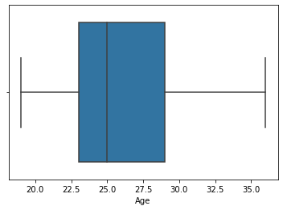

```python
sns.boxplot(buteurs['Age'])
```

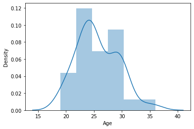

```python
sns.distplot(buteurs['Age'])
```

**On a plusieurs joueurs qui ont 23 ans et un autre groupe de 30 ans**

**Une variable qualitative**

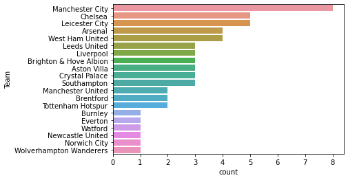

```python
sns.countplot(y=buteurs['Team'],order=buteurs['Team'].value_counts().index)
```

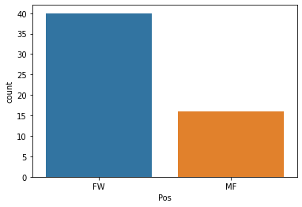

```python
sns.countplot(buteurs['Pos'])
```

Les équipes avec le plus de buteurs sont man city et chelsea

#### Analyse bivariée

**Deux variables quantitatives => nuage de points**

[figure not shown]

```python
sns.scatterplot(data=buteurs,x='Age',y='Gls',hue='Pos')
plt.title('Le nombre de but par age et par poste')
```

**Deux variables qualitatives**

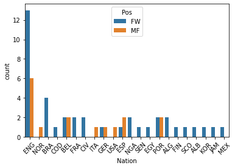

```python
sns.countplot(data=buteurs,x='Nation',hue='Pos')
plt.xticks(rotation=45);
```

**Une variable quantitative et une variable qualitative**

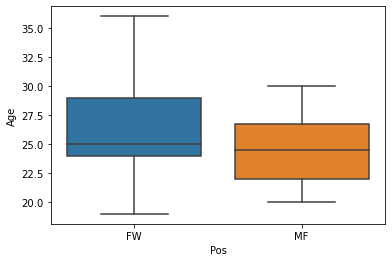

```python
sns.boxplot(data=buteurs,x='Pos',y='Age')
```

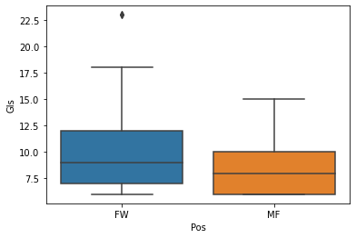

```python
sns.boxplot(data=buteurs,x='Pos',y='Gls')
```

les attaquantes sont plus vieux que les milieu, ils marquent aussi plus.

# Conclusion

**Quel joueur recommander?**

```
- ce joueur doit etre un attaquant
- Il doit être jeune
- Ne joue pas avec une grande équipe
```

```python
buteurs[(buteurs['Pos']=='FW') &(buteurs['Age']<25)&(buteurs['Team']!='Manchester City') ]
```

|  | Player | Team | Nation | Pos | Age | MP | Starts | Min | 90s | Gls | ... | G+A-PK | xG | npxG | xA | npxG+xA | xG.1 | xA.1 | xG+xA | npxG.1 | npxG+xA.1 |
| --- | --- | --- | --- | --- | --- | --- | --- | --- | --- | --- | --- | --- | --- | --- | --- | --- | --- | --- | --- | --- | --- |
| 0 | Bukayo Saka | Arsenal | ENG | FW | 19.0 | 38 | 36 | 2978.0 | 33.1 | 11.0 | ... | 0.48 | 9.7 | 8.2 | 6.9 | 15.2 | 0.29 | 0.21 | 0.50 | 0.25 | 0.46 |
| 9 | Martinelli | Arsenal | BRA | FW | 20.0 | 29 | 21 | 1860.0 | 20.7 | 6.0 | ... | 0.53 | 7.2 | 6.5 | 3.3 | 9.8 | 0.35 | 0.16 | 0.51 | 0.31 | 0.47 |
| 93 | Yoane Wissa | Brentford | COD | FW | 24.0 | 30 | 12 | 1284.0 | 14.3 | 7.0 | ... | 0.56 | 3.7 | 3.7 | 0.7 | 4.4 | 0.26 | 0.05 | 0.31 | 0.26 | 0.31 |
| 123 | Neal Maupay | Brighton & Hove Albion | FRA | FW | 24.0 | 32 | 25 | 2276.0 | 25.3 | 8.0 | ... | 0.36 | 7.7 | 6.2 | 2.2 | 8.4 | 0.30 | 0.09 | 0.39 | 0.24 | 0.33 |
| 160 | Maxwel Cornet | Burnley | CIV | FW | 24.0 | 26 | 21 | 1766.0 | 19.6 | 9.0 | ... | 0.51 | 6.7 | 5.9 | 1.5 | 7.4 | 0.34 | 0.07 | 0.42 | 0.30 | 0.38 |
| 193 | Kai Havertz | Chelsea | GER | FW | 22.0 | 29 | 22 | 1809.0 | 20.1 | 8.0 | ... | 0.55 | 9.7 | 9.7 | 2.0 | 11.6 | 0.48 | 0.10 | 0.58 | 0.48 | 0.58 |
| 226 | Odsonne Édouard | Crystal Palace | FRA | FW | 23.0 | 28 | 18 | 1564.0 | 17.4 | 6.0 | ... | 0.46 | 6.9 | 6.1 | 2.3 | 8.4 | 0.39 | 0.13 | 0.53 | 0.35 | 0.48 |
| 250 | Richarlison | Everton | BRA | FW | 24.0 | 30 | 28 | 2523.0 | 28.0 | 10.0 | ... | 0.43 | 10.2 | 7.9 | 2.4 | 10.3 | 0.36 | 0.09 | 0.45 | 0.28 | 0.37 |
| 288 | Raphael Dias Belloli | Leeds United | BRA | FW | 24.0 | 35 | 34 | 2915.0 | 32.4 | 11.0 | ... | 0.31 | 11.2 | 8.2 | 6.8 | 15.0 | 0.35 | 0.21 | 0.56 | 0.25 | 0.46 |
| 289 | Jack Harrison | Leeds United | ENG | FW | 24.0 | 35 | 32 | 2639.0 | 29.3 | 8.0 | ... | 0.31 | 4.0 | 4.0 | 2.6 | 6.6 | 0.14 | 0.09 | 0.22 | 0.14 | 0.22 |
| 323 | Harvey Barnes | Leicester City | ENG | FW | 23.0 | 32 | 24 | 2101.0 | 23.3 | 6.0 | ... | 0.69 | 6.8 | 6.8 | 4.0 | 10.8 | 0.29 | 0.17 | 0.46 | 0.29 | 0.46 |
| 330 | Ademola Lookman | Leicester City | NGA | FW | 23.0 | 26 | 16 | 1453.0 | 16.1 | 6.0 | ... | 0.37 | 5.1 | 5.1 | 1.9 | 6.9 | 0.31 | 0.12 | 0.43 | 0.31 | 0.43 |
| 359 | Diogo Jota | Liverpool | POR | FW | 24.0 | 35 | 27 | 2364.0 | 26.3 | 15.0 | ... | 0.72 | 16.1 | 16.1 | 5.5 | 21.6 | 0.61 | 0.21 | 0.82 | 0.61 | 0.82 |
| 530 | Armando Broja | Southampton | ALB | FW | 19.0 | 32 | 21 | 1975.0 | 21.9 | 6.0 | ... | 0.27 | 7.0 | 7.0 | 1.3 | 8.4 | 0.32 | 0.06 | 0.38 | 0.32 | 0.38 |
| 588 | Emmanuel Dennis | Watford | NGA | FW | 23.0 | 33 | 30 | 2581.0 | 28.7 | 10.0 | ... | 0.56 | 7.5 | 7.5 | 3.2 | 10.7 | 0.26 | 0.11 | 0.37 | 0.26 | 0.37 |
| 629 | Jarrod Bowen | West Ham United | ENG | FW | 24.0 | 36 | 34 | 2983.0 | 33.1 | 12.0 | ... | 0.66 | 11.1 | 11.1 | 5.7 | 16.8 | 0.34 | 0.17 | 0.51 | 0.34 | 0.51 |

16 rows × 30 columns